# TP3

#### 4. L’approche par validation croisée Loo (Leave One Out)

```r
# On utilise la fonction knn.cv pour prédire les données par validation LOO
pred_loo <- knn.cv(X,Y, k=15)
sum(pred_loo!=Y)/length(Y) # erreur de validation croisée LOO
```

```
## [1] 0.179
```

#### Commentaire

On trouve un taux d’erreur de validation croisée LOO autour de 18%. Cette approche est recom- mandée pour des données avec peu d’observations. Sinon, il est préférable d’utiliser une des deux approches précédentes.

#Partie 2 : On s’intéresse au jeu de données infarctus avec 101 observations et 8 variables de la partie 2 du TP 2:

#### 1. Chargeons le jeu de données et le package class.

```r
library(class)
load("/Users/moussangambe/Desktop/R/AprentissageSupervise/TP3/infarctus.rda")
```

#### 2.Estimez le taux d’erreur de la méthode *knn* avec les trois appoches suivantes:

- par découpage apprentissage/test répété B fois,
- par validation croisée 5-folds répétée B fois,
- par validation croisée LOO.

##### a. Par découpage apprentissage/test répété B fois

```r
B<-100
n<-length(infarctus$PRONO) #tirage aléatoire
err_test<-rep(NA,B)

for (b in 1:B){
taille<-sample(1:n,70)
#Données d'apprentissage
Xtrain<-infarctus[taille,-1]
Ytrain<-infarctus$PRONO[taille]
#Données test
Xtest<-infarctus[-taille,-1]
Ytest<-infarctus$PRONO[-taille]
prob<-rep(NA,nrow(Xtest))
pred_test<-class::knn(Xtrain, Xtest, Ytrain, k=10, prob =TRUE)
err_test[b] <- sum(pred_test!=Ytest)/length(Ytest)
}
# taux d'ereur moyen
mean(err_test)
```

```
## [1] 0.1816129
```

#### b. Par validation croisée 5-folds répétée B fois

Nous allons calculerle taux d’erreur de validation au découpage en 5 folds en tenant compte de la dépendance du découpage, on peut répèter B = 100 fois la procédure.Puis calculer un taux d’erreur de validation croisée moyen en faisant la moyenne des 100 valeurs obtenues avec les B = 100 découpages en 5 folds.

```r
B <- 100 # nombre de découpage
err_test <- rep(NA,B) # vecteur pour stocker les B erreurs tests
# vecteur des prediction (par validation croisée) des 101 données
pred_cv <- rep(NA, nrow(infarctus[,-1]))
# indice d'appartenance des 101 données aux 5 folds
n_folds <- 5

for (b in 1:B) {
folds_i <- sample(rep(1:n_folds, length.out = nrow(infarctus[,-1])))
  # boucle sur les folds
  for (k in 1:n_folds) {
    test_i <- which(folds_i == k) # indice des données du fold k
    Xtrain <- infarctus[-test_i,-1]
    Xtest <- infarctus[test_i,-1 ]
    Ytrain <- infarctus$PRONO[-test_i]
    pred_cv[test_i] <- class::knn(Xtrain, Xtest, Ytrain, k=10)
    }
  err_test[b] <- sum(pred_cv!=infarctus$PRONO)/length(infarctus$PRONO)
}
mean(err_test)
```

```
## [1] 1
```

#### Commentaire :

Nous avous un taux d’erreur test moyen avec la validation croisée *5-folds* répété 100 foisn, qui est égal à $100\%$.

#### b. Par validation croisée L00

```r
# On utilise la fonction knn.cv pour prédire les données par validation LOO
pred_loo <- knn.cv(infarctus[,-1],infarctus$PRONO, k=15)
sum(pred_loo!=Y)/length(Y) # erreur de validation croisée LOO
```

```
## [1] 1
```

#### Commentaire

```r
C <- matrix(c(0,10,1,0), nrow=2, ncol=2, byrow = TRUE)
rownames(C) <- colnames(C) <- levels(infarctus$PRONO)
C
```

```
##        DECES SURVIE
## DECES      0     10
## SURVIE     1      0
```

On utilise alors la règle à posteriori minimum (règle de Baye) avec la méthode *knn*(pour estimer les probabilités à postériori) et on souhaite évaluer cette règle, pour cela estimons par validation croisée *5-folds* répétée B fois.

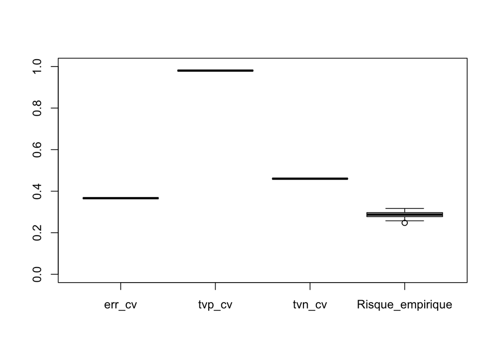

```r
B <- 100 # nombre de répétition
err_cv <- rep(NA, B)
tvp_cv <- rep(NA, B)
tvn_cv <- rep(NA, B)
Risque_empirique <- rep(NA, B)
pred_cv <- rep(NA, nrow(infarctus))
prob_cv <- rep(NA, nrow(infarctus))
# Supprimer les lignes avec des valeurs manquantes

infarctus <- infarctus[complete.cases(infarctus),]
for (b in 1:B) {
  #indice d'appartenance des 101 données aux 5-folds
  n_folds<-5
  folds_i <- sample(rep(1:n_folds, length.out = nrow(infarctus)))
  #boucle sur les folds
    for(k in 1:n_folds){
    test_i <- which(folds_i == k) # indice des données du fold k
    Xtrain <- infarctus[-test_i,-1]
    Xtest <- infarctus[test_i,-1]
    Ytrain <- infarctus$PRONO[-test_i]
    prob_i <- rep(NA, length(test_i))
    pred_i <- knn(Xtrain, Xtest, Ytrain, prob=TRUE, k=15)
    prob_i[pred_i=="DECES"] <- attr(pred_i, "prob")[pred_i=="DECES"]
    prob_i[pred_i=="SURVIE"] <- 1-attr(pred_i, "prob")[pred_i=="SURVIE"]
    prob_cv[test_i] <- prob_i
  }
  R1 <- C[2,1]*(1-prob_cv)
  R2 <- C[1,2]*prob_cv
  #prediction de la classe la moins risquée à postériori
  pred_cv[R1 <R2] <- "DECES"
  pred_cv[R2 <R1] <- "SURVIE"
  tab <- table(infarctus$PRONO, pred_cv)
  #taux de vrai positif ou sensibilité
  tvp_cv<-tab[1,1]/(tab[1,1]+tab[1,2])
  #taux de vrai négatif ou sensibilité
  tvn_cv<-tab[2,2]/(tab[2,1]+tab[2,2])
  err_cv<-(tab[1,2]*C[1,2]+tab[2,1]*C[2,1])/length(infarctus$PRONO)
  #Risque empérique
  Risque_empirique[b]<-(tab[2,1]+tab[1,2])/length(infarctus$PRONO)
}
##Représentation graphique
vec <- data.frame(err_cv, tvp_cv, tvn_cv, Risque_empirique)
boxplot(vec, ylim=c(0,1))
```